# Estadística avanzada: Preprocesado de datos

# A1 - Preproceso de datos

Autor: Eduardo Mora González

octubre 2022

```r
 library(readr)
 fichero <- read_csv("C:/Users/eduar/Dropbox/ESTUDIOS/Estadística avanzada/PEC1/gpa_row.csv")
```

Una vez cargado el fichero, la salida nos da el numero de variables que hay de cada tipo (numéricas que hay 4, lógicas que hay 4 o texto que hay 2), pero ahora vamos a ver si los datos que tenemos están dentro de los parámetros correspondientes, según se especifica en el enunciado.

```r
summary(fichero)
```

```
##       sat          tothrs             hsize               hsrank
##  Min.   : 470   Length:4137        Length:4137        Min.   :  1.00
##  1st Qu.: 940   Class :character   Class :character   1st Qu.: 11.00
##  Median :1030   Mode  :character   Mode  :character   Median : 30.00
##  Mean   :1030                                         Mean   : 52.83
##  3rd Qu.:1120                                         3rd Qu.: 70.00
##  Max.   :1540                                         Max.   :634.00
##
##      hsperc            colgpa       athlete          female
##  Min.   : 0.1667   Min.   :0.000   Mode :logical   Mode :logical
##  1st Qu.: 6.4328   1st Qu.:2.210   FALSE:3943      FALSE:2277
##  Median :14.5963   Median :2.660   TRUE :194       TRUE :1860
##  Mean   :19.2406   Mean   :2.655
##  3rd Qu.:27.7108   3rd Qu.:3.120
##  Max.   :92.0000   Max.   :4.000
##                    NA's   :41
##    white           black
##  Mode :logical   Mode :logical
##  FALSE:308       FALSE:3908
##  TRUE :3829      TRUE :229
##
##
##
##
```

Tras ver las estadísticas básicas de las variables, nos damos cuenta de lo siguiente:

**Variables numéricas** –> son: sat, hsrank, hsperc, colgpa. Las variables tothrs y hsize también son de tipo numérica pero R las ha interpretado como Strings.

**Variables lógicas** –> son: athlete, female, white y black. Estas si han sido interpretadas de manera correcta.

# 1 Normalización de las variables cualitativas

## 1.1 Athlete

Presentamos el contenido de la variable

```r
head(fichero$athlete)
```

```
## [1]  TRUE FALSE  TRUE FALSE FALSE FALSE
```

Comprobamos el tipo de variable que es

```r
class(fichero$athlete)
```

```
## [1] "logical"
```

Quitamos los espcacios y lo ponemos en mayusculas todo

```r
fichero$athlete <- toupper(fichero$athlete)
fichero$athlete <- gsub(" ", "",fichero$athlete)
class(fichero$athlete)
```

```
## [1] "character"
```

Cambiamos a variable factor y lo comprobamos

```r
fichero$athlete<- as.factor(fichero$athlete)
head(fichero$athlete)
```

```
## [1] TRUE  FALSE TRUE  FALSE FALSE FALSE
## Levels: FALSE TRUE
```

```r
class(fichero$athlete)
```

```
## [1] "factor"
```

## 1.2 Female

Presentamos el contenido de la variable

```r
head(fichero$female)
```

```
## [1]  TRUE FALSE FALSE FALSE FALSE  TRUE
```

Comprobamos el tipo de variable que es

```r
class(fichero$female)
```

```
## [1] "logical"
```

Quitamos los espacios y lo ponemos en mayusculas todo

```r
fichero$female <- toupper(fichero$female)
fichero$female <- gsub(" ", "",fichero$female)
class(fichero$female)
```

```
## [1] "character"
```

Cambiamos a variable factor y lo comprobamos

```r
fichero$female<- as.factor(fichero$female)
head(fichero$female)
```

```
## [1] TRUE  FALSE FALSE FALSE FALSE TRUE
## Levels: FALSE TRUE
```

```r
class(fichero$female)
```

```
## [1] "factor"
```

## 1.3 Black

Presentamos el contenido de la variable

```r
head(fichero$black)
```

```
## [1] FALSE FALSE FALSE FALSE FALSE FALSE
```

Comprobamos el tipo de variable que es

```r
class(fichero$black)
```

```
## [1] "logical"
```

Quitamos los espacios y lo ponemos en mayusculas todo

```r
fichero$black <- toupper(fichero$black)
fichero$black <- gsub(" ", "",fichero$black)
class(fichero$black)
```

```
## [1] "character"
```

Cambiamos a variable factor y lo comprobamos

```r
fichero$black<- as.factor(fichero$black)
head(fichero$black)
```

```
## [1] FALSE FALSE FALSE FALSE FALSE FALSE
## Levels: FALSE TRUE
```

```r
class(fichero$black)
```

```
## [1] "factor"
```

## 1.4 White

Presentamos el contenido de la variable

```r
head(fichero$white)
```

```
## [1] FALSE  TRUE  TRUE  TRUE  TRUE  TRUE
```

Comprobamos el tipo de variable que es

```r
class(fichero$white)
```

```
## [1] "logical"
```

```r
fichero$black <- toupper(fichero$black)
fichero$black <- gsub(" ", "",fichero$black)
class(fichero$black)
```

```
## [1] "character"
```

Cambiamos a variable factor y lo comprobamos

```r
fichero$white<- as.factor(fichero$white)
head(fichero$white)
```

```
## [1] FALSE TRUE  TRUE  TRUE  TRUE  TRUE
## Levels: FALSE TRUE
```

```r
class(fichero$white)
```

```
## [1] "factor"
```

# 2 Normalización de las variables cuantitativas

## 2.1 Nota de acceso

Presentamos el contenido de la variable

```r
head(fichero$sat)
```

```
## [1]  920 1170  810  940 1180  980
```

Comprobamos el tipo de variable que es

```r
class(fichero$sat)
```

```
## [1] "numeric"
```

La variable se adapta a la normalización deseada.

## 2.2 Horas totales cursadas al semestre

Presentamos el contenido de la variable

```r
head(fichero$tothrs)
```

```
## [1] "43h"  "18h"  "14h"  "40h"  "18h"  "114h"
```

Comprobamos el tipo de variable que es

```r
class(fichero$tothrs)
```

```
## [1] "character"
```

Debemos quitar la “h” final y convertir la variable en numérica

```r
library(stringr)

fichero$tothrs <- str_replace (fichero$tothrs, "h", "")
head(fichero$tothrs)
```

```
## [1] "43"  "18"  "14"  "40"  "18"  "114"
```

```r
fichero$tothrs <- as.numeric(fichero$tothrs)
```

Comprobamos el tipo de variable que es

```r
class(fichero$tothrs)
```

```
## [1] "numeric"
```

Ahora la variable se adapta a la normalización deseada.

## 2.3 Nota media del estudiante al final del primer semestre

Presentamos el contenido de la variable

```r
head(fichero$colgpa)
```

```
## [1] 2.04 4.00 1.78 2.42 2.61 3.03
```

Comprobamos el tipo de variable que es

```r
class(fichero$colgpa)
```

```
## [1] "numeric"
```

La variable se adapta a la normalización deseada.

## 2.4 Número total de estudiants en la cohorte de graduados del bachillerato

Presentamos el contenido de la variable

```r
head(fichero$hsize)
```

```
## [1] "0.1"       "9.3999996" "1.1900001" "5.71"      "2.1400001" "2.6800001"
```

Comprobamos el tipo de variable que es

```r
class(fichero$hsize)
```

```
## [1] "character"
```

Debemos convertir la variable en numérica

```r
library(stringr)

fichero$hsize <- str_replace (fichero$hsize, ",", ".")
head(fichero$hsize)
```

```
## [1] "0.1"       "9.3999996" "1.1900001" "5.71"      "2.1400001" "2.6800001"
```

```r
fichero$hsize <- as.numeric(fichero$hsize)
```

Comprobamos el tipo de variable que es

```r
class(fichero$hsize)
```

```
## [1] "numeric"
```

Ahora la variable se adapta a la normalización deseada.

## 2.5 Ranking relativo del estudiante

Presentamos el contenido de la variable

```r
head(fichero$hsperc)
```

```
## [1] 40.00000 20.31915 35.29412 44.13310 40.18692 15.29851
```

Comprobamos el tipo de variable que es

```r
class(fichero$hsperc)
```

```
## [1] "numeric"
```

```r
fichero$hsperc <- signif(fichero$hsperc,  digits =3)
head(fichero$hsperc)
```

```
## [1] 40.0 20.3 35.3 44.1 40.2 15.3
```

La variable se adapta a la normalización deseada.

# 3 Valores atípicos

Vemos una vez normalizadas las variables, en que rango se encuentran y si están dentro de lo deseado.

```r
summary(fichero)
```

```
##       sat           tothrs           hsize          hsrank
##  Min.   : 470   Min.   :  6.00   Min.   :0.03   Min.   :  1.00
##  1st Qu.: 940   1st Qu.: 17.00   1st Qu.:1.65   1st Qu.: 11.00
##  Median :1030   Median : 47.00   Median :2.51   Median : 30.00
##  Mean   :1030   Mean   : 52.83   Mean   :2.80   Mean   : 52.83
##  3rd Qu.:1120   3rd Qu.: 80.00   3rd Qu.:3.68   3rd Qu.: 70.00
##  Max.   :1540   Max.   :137.00   Max.   :9.40   Max.   :634.00
##
##      hsperc           colgpa       athlete       female       white
##  Min.   : 0.167   Min.   :0.000   FALSE:3943   FALSE:2277   FALSE: 308
##  1st Qu.: 6.430   1st Qu.:2.210   TRUE : 194   TRUE :1860   TRUE :3829
##  Median :14.600   Median :2.660
##  Mean   :19.241   Mean   :2.655
##  3rd Qu.:27.700   3rd Qu.:3.120
##  Max.   :92.000   Max.   :4.000
##                   NA's   :41
##     black
##  Length:4137
##  Class :character
##  Mode  :character
##
##
##
##
```

La variable **tothrs**` y **hsrank** está dentro de los parámetros normales.

La variable **colgpa** está en escala de 0 a 4 puntos, por lo que está de forma correcta. Además esta variable tiene 41 campos nulos.

Para la variable **hsperc** se va a comprobar si el cálculo se ha hecho de manera correcta, para ello se comprueba si son iguales los valores, si no se sustituye, y se cuenta los distintos. Finalmente se muestra el número de errores que ha tenido los datos.

```r
distintos = 0

for(i in 1: length(fichero$hsperc)){

  calculo <- signif((fichero$hsrank[i] / fichero$hsize[i]),  digits =3)

  iguales <- identical(calculo, fichero$hsperc[i])


  if(iguales==FALSE){
    fichero$hsperc[i]<-calculo
    distintos = distintos + 1
  }

}

distintos
```

```
## [1] 12
```

Para la variable **hsize** nos damos cuenta de que esta dentro de los rangos, pero tiene valores atípicos, como se puede comprobar en el boxplot siguiente:

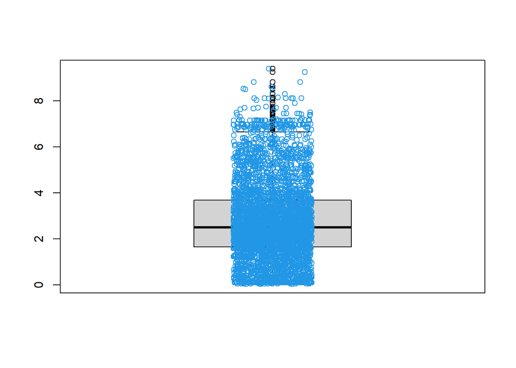

```r
boxplot(fichero$hsize)

# Points
stripchart(fichero$hsize,              # Data
           method = "jitter", # Random noise
           pch = 1,          # Pch symbols
           col = 4,           # Color of the symbol
           vertical = TRUE,   # Vertical mode
           add = TRUE)        # Add it over
```

La variable **SAT** está en escala de 400 a 1600 puntos, pero tiene valores atípicos, como se puede comprobar en el boxplot siguiente:

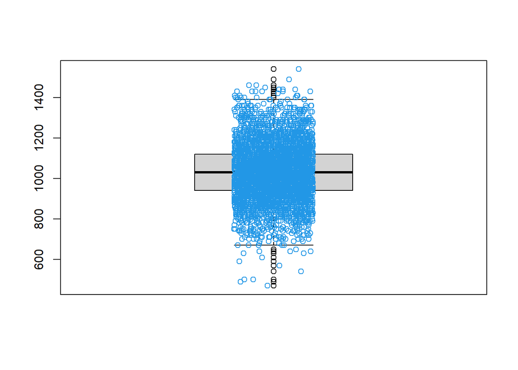

```r
boxplot(fichero$sat)

# Points
stripchart(fichero$sat,              # Data
           method = "jitter", # Random noise
           pch = 1,          # Pch symbols
           col = 4,           # Color of the symbol
           vertical = TRUE,   # Vertical mode
           add = TRUE)        # Add it over
```

# 4 Imputación de valores

Lo primero que vamos a hacer es dividir los registros entre hombre y mujer

```r
fichero_mujer  <- fichero
fichero_mujer  <- fichero_mujer [fichero_mujer$female == TRUE ,]
fichero_hombre <- fichero
fichero_hombre <- fichero_hombre[fichero_hombre$female == FALSE ,]

summary(fichero_hombre$colgpa)
```

```
##    Min. 1st Qu.  Median    Mean 3rd Qu.    Max.    NA's
##    0.00    2.12    2.57    2.59    3.06    4.00      24
```

```r
summary(fichero_mujer$colgpa)
```

```
##    Min. 1st Qu.  Median    Mean 3rd Qu.    Max.    NA's
##   0.210   2.325   2.740   2.734   3.170   4.000      17
```

Comprobamos que para los hombres hay 24 nulos y para las mujeres 17.

Hacemos la imputación para las mujeres, lo mostramos y los añadimos a la lista de mujeres

```r
library(VIM)
imputacion_mujer <- kNN(fichero_mujer, k=11)

imputacion_mujer$colgpa[imputacion_mujer$colgpa_imp=='TRUE']
```

```
##  [1] 3.26 2.60 2.82 2.81 2.89 2.94 2.59 2.78 2.36 2.19 2.72 2.75 2.38 2.73 2.11
## [16] 2.41 2.46
```

```r
fichero_mujer$colgpa <- imputacion_mujer$colgpa

summary(fichero_mujer$colgpa)
```

```
##    Min. 1st Qu.  Median    Mean 3rd Qu.    Max.
##   0.210   2.330   2.740   2.733   3.170   4.000
```

Hacemos la imputación para los hombres, lo mostramos y los añadimos a la lista de hombres

```r
library(VIM)
imputacion_hombre <- kNN(fichero_hombre, k=11)

imputacion_hombre$colgpa[imputacion_hombre$colgpa_imp=='TRUE']
```

```
##  [1] 2.47 2.65 2.37 2.18 2.15 2.26 2.72 2.26 2.43 2.81 2.69 3.46 2.70 2.20 2.50
## [16] 2.68 2.35 3.00 2.42 2.26 3.23 2.25 3.41 1.68
```

```r
fichero_hombre$colgpa <- imputacion_hombre$colgpa

summary(fichero_hombre$colgpa)
```

```
##    Min. 1st Qu.  Median    Mean 3rd Qu.    Max.
##   0.000   2.120   2.570   2.589   3.060   4.000
```

Unimos las dos listas con los datos ya imputados.

```r
fichero_2 <- rbind(fichero_hombre, fichero_mujer)
summary(fichero_2)
```

```
##       sat           tothrs           hsize          hsrank
##  Min.   : 470   Min.   :  6.00   Min.   :0.03   Min.   :  1.00
##  1st Qu.: 940   1st Qu.: 17.00   1st Qu.:1.65   1st Qu.: 11.00
##  Median :1030   Median : 47.00   Median :2.51   Median : 30.00
##  Mean   :1030   Mean   : 52.83   Mean   :2.80   Mean   : 52.83
##  3rd Qu.:1120   3rd Qu.: 80.00   3rd Qu.:3.68   3rd Qu.: 70.00
##  Max.   :1540   Max.   :137.00   Max.   :9.40   Max.   :634.00
##      hsperc           colgpa       athlete       female       white
##  Min.   : 0.167   Min.   :0.000   FALSE:3943   FALSE:2277   FALSE: 308
##  1st Qu.: 6.430   1st Qu.:2.210   TRUE : 194   TRUE :1860   TRUE :3829
##  Median :14.600   Median :2.660
##  Mean   :19.238   Mean   :2.654
##  3rd Qu.:27.700   3rd Qu.:3.120
##  Max.   :92.000   Max.   :4.000
##     black
##  Length:4137
##  Class :character
##  Mode  :character
##
##
##
```

# 5 Creación de una nueva variable

Con la calificación dada, se asigna el valor de la variable categórica. Se ha establecido los intervalos para cada letra según el enunciado.

```r
fichero_2["gpaletter"] <- cut(fichero_2$colgpa, breaks = c(-0.01,1.49,2.49,3.49,4), labels = c("D", "C", "B", "A"))

head(fichero_2)
```

```
## # A tibble: 6 x 11
##     sat tothrs hsize hsrank hsperc colgpa athlete female white black gpaletter
##   <dbl>  <dbl> <dbl>  <dbl>  <dbl>  <dbl> <fct>   <fct>  <fct> <chr> <fct>
## 1  1170     18  9.40    191   20.3   4    FALSE   FALSE  TRUE  FALSE A
## 2   810     14  1.19     42   35.3   1.78 TRUE    FALSE  TRUE  FALSE C
## 3   940     40  5.71    252   44.1   2.42 FALSE   FALSE  TRUE  FALSE C
## 4  1180     18  2.14     86   40.2   2.61 FALSE   FALSE  TRUE  FALSE B
## 5   880     78  3.11    161   51.8   1.84 FALSE   FALSE  FALSE FALSE C
## 6   980     55  2.68    101   37.7   3.05 FALSE   FALSE  TRUE  FALSE B
```

```r
tail(fichero_2)
```

```
## # A tibble: 6 x 11
##     sat tothrs hsize hsrank hsperc colgpa athlete female white black gpaletter
##   <dbl>  <dbl> <dbl>  <dbl>  <dbl>  <dbl> <fct>   <fct>  <fct> <chr> <fct>
## 1  1000     18 1.41      25   17.7   2.33 FALSE   TRUE   TRUE  FALSE C
## 2  1020     75 1         41   41     1.97 FALSE   TRUE   TRUE  FALSE C
## 3  1180     47 2.3       20    8.7   3.36 FALSE   TRUE   TRUE  FALSE B
## 4   990     49 2.33      89   38.2   2.24 FALSE   TRUE   TRUE  FALSE C
## 5   900     50 0.1        2   20     2.46 FALSE   TRUE   TRUE  FALSE C
## 6   980     12 0.350     23   65.7   2.83 FALSE   TRUE   TRUE  FALSE B
```

# 6 Estudio descriptivo

## 6.1 Estudio descriptivo de las variables cualitativas

### 6.1.1 Athlete en porcentaje de atletas

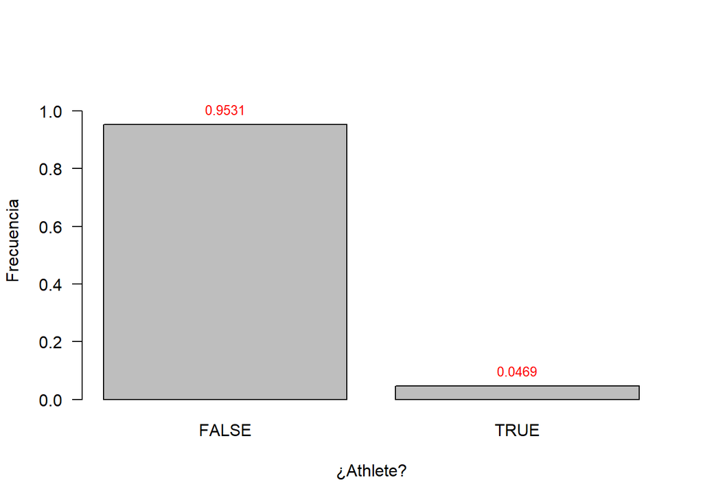

```r
tabla1 <- table(fichero_2$athlete)
tabla1 <- prop.table(tabla1)

xx <- barplot(tabla1, ylim=c(0,1.1), xlab='¿Athlete?', ylab='Frecuencia', las=1)
text(x=xx, y=tabla1, pos=3, cex=0.8, col="red", label=round(tabla1, 4))
```

Como se puede ver, hay un mayor número de personas que no practican deporte respecto a las que si las practican.

### 6.1.2 Athlete en porcentaje de atletas en función del sexo

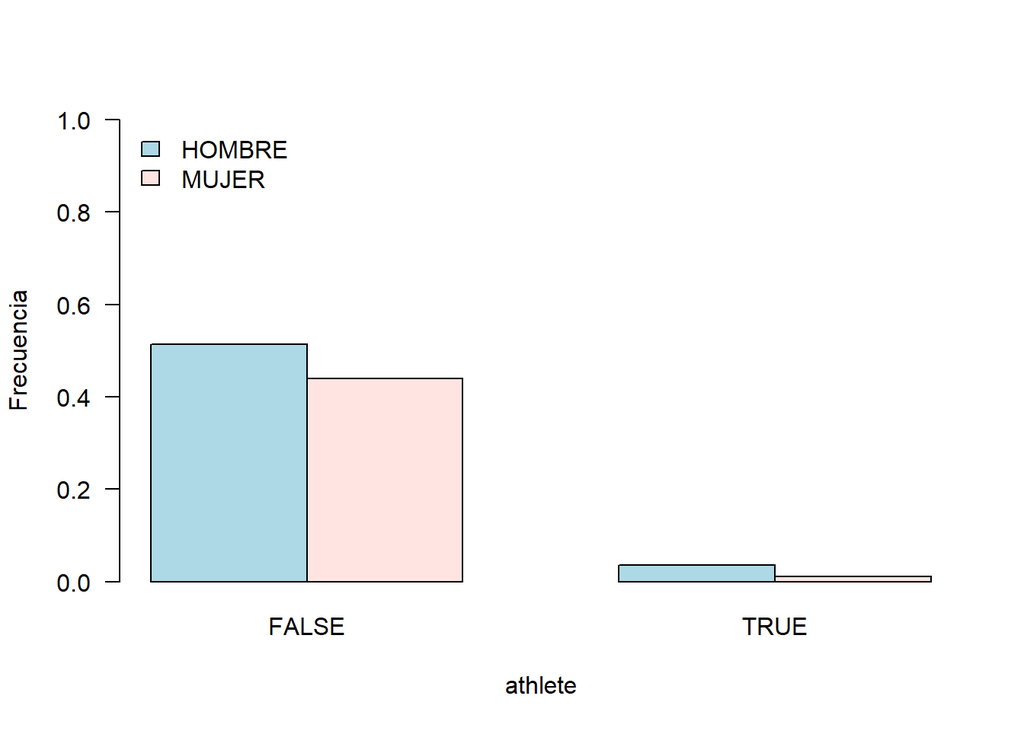

```r
tabla2 <- table(fichero_2$female, fichero_2$athlete)
tabla2 <- prop.table(tabla2)
valores <- c("HOMBRE", "MUJER")

barplot(tabla2, beside = TRUE, las=1,
        xlab='athlete', ylab='Frecuencia',
        col = c("lightblue", "mistyrose"),
        ylim = c(0,1))
legend('topleft', legend=valores, bty='n',
       fill=c("lightblue", "mistyrose"))
```

A nivel visual se puede ver, que los hombres hacen mas deporte que las mujeres.

## 6.2 Estudio descriptivo de las variables cuantitativas

### 6.2.1 Estudio descriptivo de las variables cuantitativas “sat”, “tothrs”, “hsize”, “hsrank”.

Se va a generar histogramas para verificar la distribución de las variables numéricas

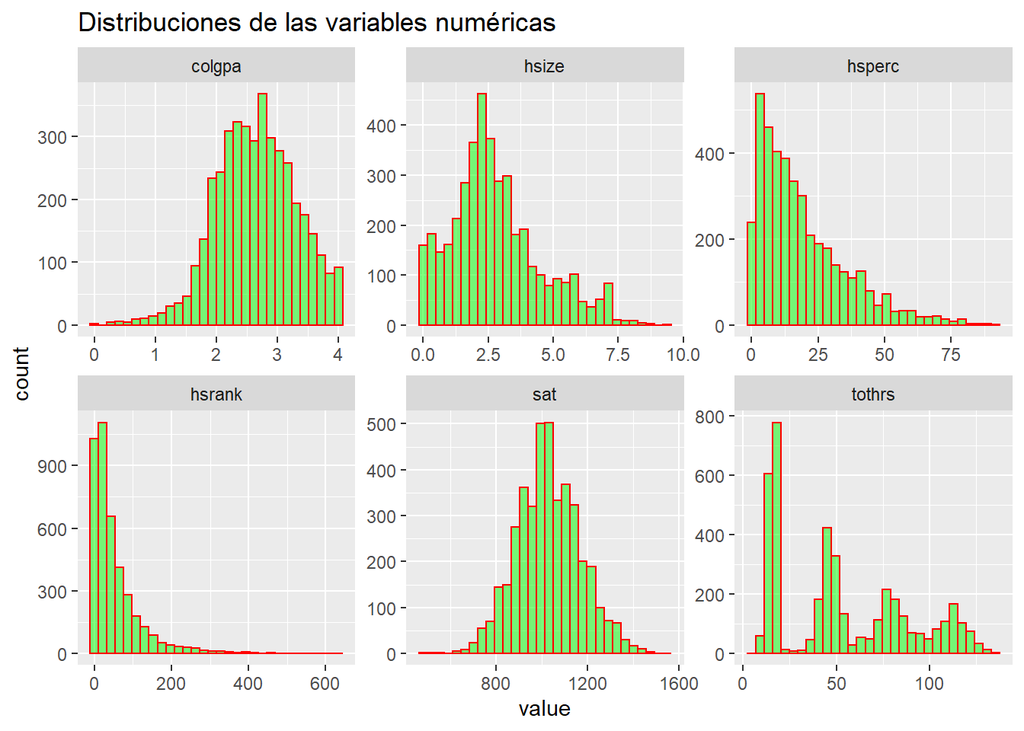

```r
library(purrr)
library(tidyr)
library(ggplot2)

fichero_2 %>%
  keep(is.numeric) %>%
  gather() %>%
  ggplot(aes(value)) +
    facet_wrap(~ key, scales = "free") +
    geom_histogram(col="red",
                   fill="green",
                   alpha = 0.5,) +
    ggtitle("Distribuciones de las variables numéricas")
```

### 6.2.2 Distribución de los valores de “sat”

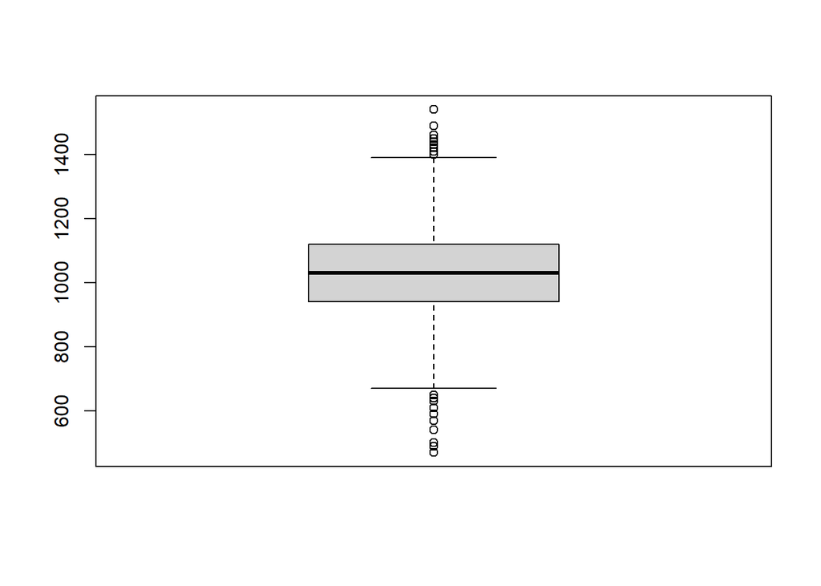

```r
boxplot(fichero_2$sat)
```

### Distribución de los valores de “sat” por sexo

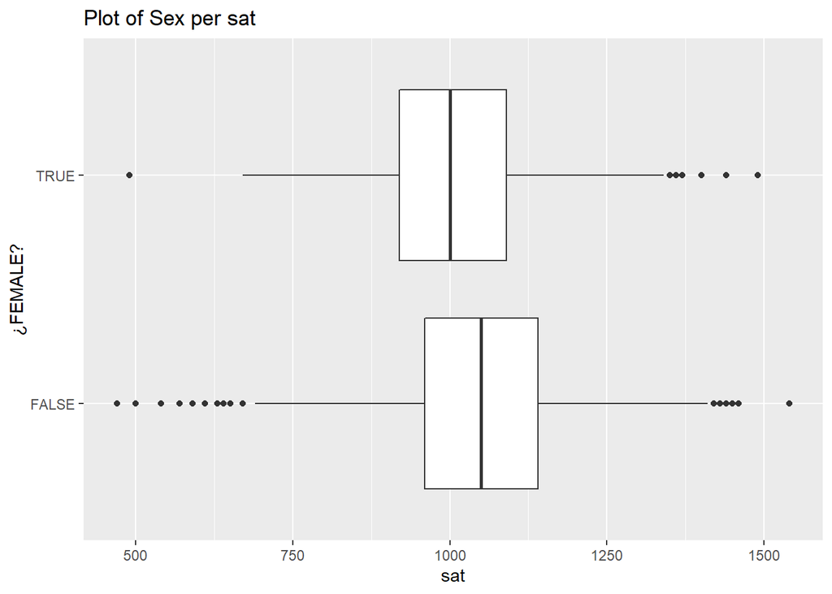

```r
ggplot(fichero_2, aes(x=sat, y=female, fill=sat)) +
  geom_boxplot()+
  labs(title="Plot of Sex per sat",x="sat", y = "¿FEMALE?")
```

### 6.2.3 Tabla con diversas medidas de tendencia central y dispersión, robustas y no robustas.

```r
Cabecera <- c("Estimadores","sat", "tothrs", "hsize", "hsrank" )
sat <- c(mean(fichero_2$sat),median(fichero_2$sat),mean(fichero_2$sat,trim=0.05),sd(fichero_2$sat),IQR(fichero_2$sat), mad(fichero_2$sat) )
tothrs <- c(mean(fichero_2$tothrs),median(fichero_2$tothrs),mean(fichero_2$tothrs,trim=0.05),sd(fichero_2$tothrs),IQR(fichero_2$tothrs), mad(fichero_2$tothrs) )
hsize<- c(mean(fichero_2$hsize),median(fichero_2$hsize),mean(fichero_2$hsize,trim=0.05),sd(fichero_2$hsize),IQR(fichero_2$hsize), mad(fichero_2$hsize) )
hsrank<- c(mean(fichero_2$hsrank),median(fichero_2$hsrank),mean(fichero_2$hsrank,trim=0.05),sd(fichero_2$hsrank),IQR(fichero_2$hsrank), mad(fichero_2$hsrank) )
Estimadores <- c("Media", "Mediana","Media recortada","Desviación estándar","RIC","DAM")

tabla_medidas <- data.frame(
  "Estimadores" = Estimadores,
  "sat" = sat,
  "tothrs" = tothrs,
  "hsize" = hsize,
  "hsrank" = hsrank
)

tabla_medidas
```

```
##           Estimadores       sat   tothrs    hsize   hsrank
## 1               Media 1030.3312 52.83225 2.799727 52.83007
## 2             Mediana 1030.0000 47.00000 2.510000 30.00000
## 3     Media recortada 1029.4792 51.27060 2.711791 43.99383
## 4 Desviación estándar  139.4014 35.32959 1.736579 64.68358
## 5                 RIC  180.0000 63.00000 2.030000 59.00000
## 6                 DAM  133.4340 45.96060 1.423296 35.58240
```

# 7 Archivo final

```r
   head(fichero_2)
```

```
## # A tibble: 6 x 11
##     sat tothrs hsize hsrank hsperc colgpa athlete female white black gpaletter
##   <dbl>  <dbl> <dbl>  <dbl>  <dbl>  <dbl> <fct>   <fct>  <fct> <chr> <fct>
## 1  1170     18  9.40    191   20.3   4    FALSE   FALSE  TRUE  FALSE A
## 2   810     14  1.19     42   35.3   1.78 TRUE    FALSE  TRUE  FALSE C
## 3   940     40  5.71    252   44.1   2.42 FALSE   FALSE  TRUE  FALSE C
## 4  1180     18  2.14     86   40.2   2.61 FALSE   FALSE  TRUE  FALSE B
## 5   880     78  3.11    161   51.8   1.84 FALSE   FALSE  FALSE FALSE C
## 6   980     55  2.68    101   37.7   3.05 FALSE   FALSE  TRUE  FALSE B
```

```r
   write.csv(fichero_2, file = "gpa_clean.csv")
```

# 8 Informe ejecutivo

## 8.1 Tabla resumen del preprocesamiento

[output not shown]

## 8.2 Resumen estadístico

A nivel general, y tras realizar un estudio sobre el conjunto de datos, podemos observar que muchas variables están relacionadas entre sí, ya que unas dependen de las otras, o simplemente son un calculo o división de conjuntos de la otra.

Inicialmente, podemos ver la variable **ColgPa** nos muestra que el mayor numero de los estudiantes están entre el 2 y el 3, habiendo a su vez una cantidad mayor de mejores calificaciones (superiores a 3) que peores calificaciones (inferior a 2). Para complementar la variable anterior, se ha creado la variable **gpaletter**, en la cual se obtiene a partir de las calificaciones obtenidas, y se dividen en varios intervalos.

Por otro lado, tenemos la variable **hsperc** muestra el ranking relativo de los estudiantes, el valor de esta variable depende de la variable ** hsrank** que es el ranking de los estudiantes, donde se puede observar que el grueso de estudiantes del dataset están entre los 100 primeros puntos del ranking. También la variable **hsperc** depende de la variable **hsize** la cual nos dice el porcentaje de graduados, en donde el mayor pico de estudiantes esta un ~2,5% (lo que seria 250 estudiantes). La variable **Sat** aunque siempre se ha encontrado dentro de los rangos, ha tenido datos atípicos, en el sentido de que existen datos muy cerca de los límites, y bastantes datos alejado de la media.

Si cambiamos las tornas a las variables cualitativas, nos damos cuenta de que hay más hombres que mujeres tal y como se indica en la variable **Female**, que hay un numero bajo de deportistas en la universidad como indica la variable **Athlete** y que hay un número de personas que no son ni Blancas ni Negras, según la variables ** White** y ** black**, ya que la proporción de valores afirmativos y negativos no coinciden.

Además, comparando las variables como se ha hecho en el estudio descriptivo, nos damos cuenta de que la nota media **Sat** de los hombres es mas alta que la de las mujeres.